# 准备说明

这里给出的操作以Ｌinux为主。 使用之前确保一下几点：

电脑已经连网  
键盘鼠标不罢工  
成为七月在线学员

# 1.找到私信内容

[figure not shown]

打开GPU信息私信

[figure not shown]

找到图中红框所列信息(每个人的信息都不同,自己切记保管好账号和密码以及ip地址)

[figure not shown]

# 2.在本地Linux上生成密钥对

ssh-keygen -t rsa -C 'fan'  
//随便起个名字吧(我的名字叫fan), 全部按回车默认．地址按回车默认，秘钥按回车默认跳过．

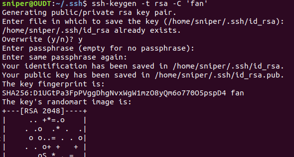

# ３.将公钥复制到远程服务器上(其他文件传输也用这种方式)

scp ~/.ssh/id_rsa.pub julyedu_481243@139.196.78.189:~/ //julyedu_481243改成你自己私信里的账号,139.196.78.189改成你私信中的ip地址,输入私信里的密码．~/.ssh/id_rsa.pub是要传输的文件地址，~/是要传送的目的地

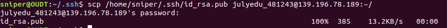

# ４.登录远程服务器，将id_rsa.pub内容复制到authorized_keys中,步骤如下:

先登录远程服务器  
在终端输入  
ssh julyedu_481243@139.196.78.189  
//julyedu_481243改成你自己的用户名,139.196.78.189改成你私信中的ip地址.回车后输入私信里的密码，看到julyedu开头,表示登录成功．

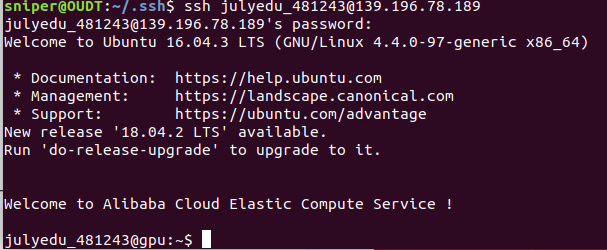

再执行：  
mkdir ~/.ssh //建立.ssh目录  
cd ~/.ssh //进入目录  
cat ~/id_rsa.pub >> ~/.ssh/authorized_keys //将id_rsa.pub内容复制到authorized_keys中 cat ~/.ssh/authorized_keys //查看一下是否有公钥的内容存在

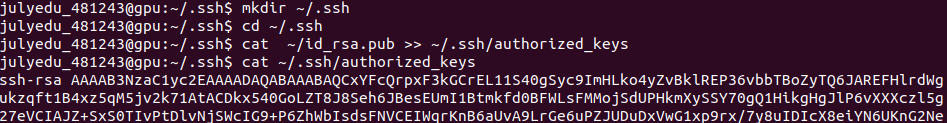

# 5.回到本地的Linux上部署快捷登录

cd ~/.ssh/  
vim config

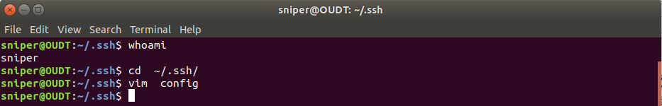

进入编辑器后添加如下  
Host july #自定义别名，建议设成“july”，这样很容易记忆（不用担心安全问题）  
HostName 139.196.78.189 #替换为你的ssh服务器ip或domain  
Port 22 #ssh服务器端口，默认为22  
User julyedu_481243 #ssh服务器用户名  
IdentityFile ~/.ssh/id_rsa #第一个步骤生成的公钥文件对应的私钥文地址  
按ESC,再输入:进入底线模式，输入wq保存退出

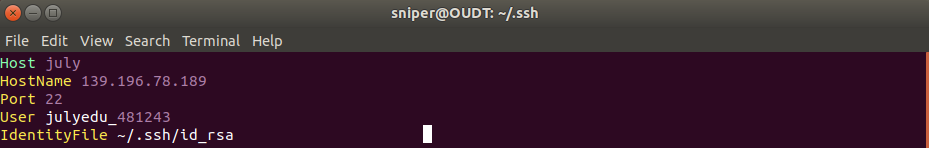

# ６．验证

本地Linux终端输入： ssh july  
这样一下子就进入服务器了，并且不用输入密码了，是不是很方便？